# Principal Component Analysis (PCA)

Evan

8/31/2018

# 1 Goals

1. Demonstrate PCA using the [iris dataset](https://en.wikipedia.org/wiki/Iris_flower_data_set).
2. Walkthrough [this excellent example](https://stats.stackexchange.com/questions/72839/how-to-use-r-prcomp-results-for-prediction) for a machine learning application.
3. Update your ggplot-ing skills as PCA produces excellent visualizations.

### 1.0.1 Resources

There are many resources available to learn about ordination techniques such as PCA. [Start here!](http://ordination.okstate.edu/)

# 2 Load the data

```r
# load the data that is pre-baked into R
data(iris)

# or
# iris = read.csv("./iris.csv")

# view its structure
str(iris)
```

```
## 'data.frame':    150 obs. of  5 variables:
##  $ Sepal.Length: num  5.1 4.9 4.7 4.6 5 5.4 4.6 5 4.4 4.9 ...
##  $ Sepal.Width : num  3.5 3 3.2 3.1 3.6 3.9 3.4 3.4 2.9 3.1 ...
##  $ Petal.Length: num  1.4 1.4 1.3 1.5 1.4 1.7 1.4 1.5 1.4 1.5 ...
##  $ Petal.Width : num  0.2 0.2 0.2 0.2 0.2 0.4 0.3 0.2 0.2 0.1 ...
##  $ Species     : Factor w/ 3 levels "setosa","versicolor",..: 1 1 1 1 1 1 1 1 1 1 ...
```

```r
# see how our classes are distributed
table(iris$Species)
```

```
##
##     setosa versicolor  virginica
##         50         50         50
```

### 2.0.1 What do we want to accomplish, exactly?

# 3 Install + library necessary packages

# 4 Setup

### 4.0.1 Scale the numeric variables

```r
# copy species into into its own variable
species = iris$Species

# create a subset named "numeric" that contains only the numeric variables
numeric = iris[,1:4]
head(numeric)
```

```
##   Sepal.Length Sepal.Width Petal.Length Petal.Width
## 1          5.1         3.5          1.4         0.2
## 2          4.9         3.0          1.4         0.2
## 3          4.7         3.2          1.3         0.2
## 4          4.6         3.1          1.5         0.2
## 5          5.0         3.6          1.4         0.2
## 6          5.4         3.9          1.7         0.4
```

```r
# scale the numeric data
scaled = data.frame(scale(numeric, center = TRUE, scale = TRUE))
head(scaled)
```

```
##   Sepal.Length Sepal.Width Petal.Length Petal.Width
## 1   -0.8976739  1.01560199    -1.335752   -1.311052
## 2   -1.1392005 -0.13153881    -1.335752   -1.311052
## 3   -1.3807271  0.32731751    -1.392399   -1.311052
## 4   -1.5014904  0.09788935    -1.279104   -1.311052
## 5   -1.0184372  1.24503015    -1.335752   -1.311052
## 6   -0.5353840  1.93331463    -1.165809   -1.048667
```

```r
# combine species and scaled into the dataset we will use
data = cbind(species, scaled)
head(data)
```

```
##   species Sepal.Length Sepal.Width Petal.Length Petal.Width
## 1  setosa   -0.8976739  1.01560199    -1.335752   -1.311052
## 2  setosa   -1.1392005 -0.13153881    -1.335752   -1.311052
## 3  setosa   -1.3807271  0.32731751    -1.392399   -1.311052
## 4  setosa   -1.5014904  0.09788935    -1.279104   -1.311052
## 5  setosa   -1.0184372  1.24503015    -1.335752   -1.311052
## 6  setosa   -0.5353840  1.93331463    -1.165809   -1.048667
```

# 5 Density curve exploration

Construct density curves to see how the scaled numeric variables look

```r
# reshape the data to long / univariate format for ease of ggplot-ing
library(reshape2)
scaled_melt = melt(data, id.vars = "species")
head(scaled_melt)
```

```
##   species     variable      value
## 1  setosa Sepal.Length -0.8976739
## 2  setosa Sepal.Length -1.1392005
## 3  setosa Sepal.Length -1.3807271
## 4  setosa Sepal.Length -1.5014904
## 5  setosa Sepal.Length -1.0184372
## 6  setosa Sepal.Length -0.5353840
```

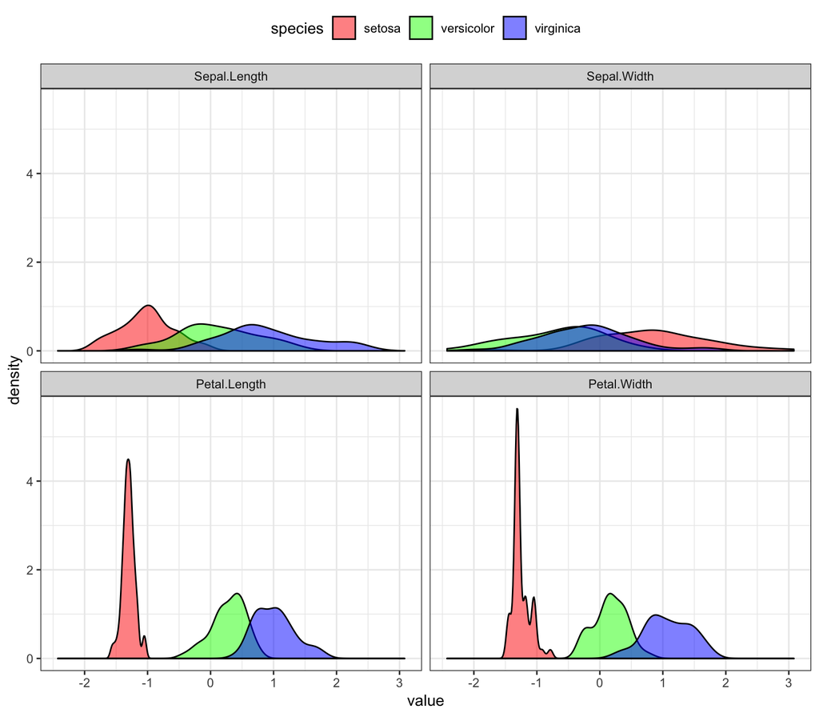

```r
# explore the data using density curves
ggplot(scaled_melt, aes(x = value, fill = species)) +
  geom_density(alpha = 0.5) +
  theme_bw() +
  facet_wrap(~variable) +
  theme(legend.position = "top") +
  scale_fill_manual(values = c("red", "green", "blue"))
```

### 5.0.1 The value of unsupervised approaches

Since we are not trying to predict the value of any target variable like in supervised approaches, the value of unsupervised machine learning can be to see how data separate based solely on the nature of their features. This is a major value, as we can include all of the data at once, and just see how it sorts!

> NOTE: At more intermediate levels, unsupervised approaches are highly useful for optimizing other machine learning algorithms.

# 6 What is PCA?

In short:  
* A powerful linear transformation technique to explore patterns in data and highly correlated variables.  
* Useful for distilling variation across many variables onto a reduced feature space (e.g., a 2D scatterplot) while maintaining the integrity of the data.

### 6.0.1 How to make it work:

1. Scale the data
2. Compute Eigenpairs (via eigendecomposition on covariance matrix or correlation matrix; singular value decomposition).  
   2.1) Eigenvectors - principal component; stored in projection matrix *W*. Defines directions of the new feature space.  
   2.2) Eigenvalues - explain magnitudes of the Eigenvector and how much variance is found along each axis.
3. Choose the eigenvectors *k* with largest eigenvalues.
4. Use *W* to transform an original dataset *A* to the *k*-dimensional feature subspace named *Y*.

### 6.0.2 Math stuff (not covered today)

To learn more about the math behind it all, check out:  
* pages 230-237 and Chapter 10 from the always useful [James et al’s **An introduction to statistical learning - with applications in R**](http://www-bcf.usc.edu/~gareth/ISL/),  
* [Jordan’s (1987) **An introduction to linear algebra in parallel distributed processing**](https://www.cs.cmu.edu/afs/cs/academic/class/15883-f15/readings/jordan-1986-ch9.pdf), and  
* [Kolter and Do’s (2015) **Linear algebra review and reference**](http://www.cs.cmu.edu/~zkolter/course/15-884/linalg-review.pdf).

# 7 `princomp` PCA

Like most variables in R, we can unpack their contents. View the names of our `pca_princomp` object, print the scores, view the component loadings, and place them inside a dataframe

```r
# view the things we can unpack inside pca_princomp
names(pca_princomp)
```

```
## [1] "sdev"     "loadings" "center"   "scale"    "n.obs"    "scores"
## [7] "call"
```

```r
# print the scores
head(pca_princomp$scores)
```

```
##         Comp.1     Comp.2      Comp.3      Comp.4
## [1,] -2.264703  0.4800266  0.12770602  0.02416820
## [2,] -2.080961 -0.6741336  0.23460885  0.10300677
## [3,] -2.364229 -0.3419080 -0.04420148  0.02837705
## [4,] -2.299384 -0.5973945 -0.09129011 -0.06595556
## [5,] -2.389842  0.6468354 -0.01573820 -0.03592281
## [6,] -2.075631  1.4891775 -0.02696829  0.00660818
```

```r
# view component loadings
pca_princomp$loadings
```

```
##
## Loadings:
##              Comp.1 Comp.2 Comp.3 Comp.4
## Sepal.Length  0.521  0.377  0.720  0.261
## Sepal.Width  -0.269  0.923 -0.244 -0.124
## Petal.Length  0.580        -0.142 -0.801
## Petal.Width   0.565        -0.634  0.524
##
##                Comp.1 Comp.2 Comp.3 Comp.4
## SS loadings      1.00   1.00   1.00   1.00
## Proportion Var   0.25   0.25   0.25   0.25
## Cumulative Var   0.25   0.50   0.75   1.00
```

```r
# place the scores for the first three principal components inside a dataframe
pca_princomp_df = data.frame(pca_princomp$scores[,1], pca_princomp$scores[,2], pca_princomp$scores[,3])

# add a column for species
pca_princomp_df$species = data$species

# rename athe columns
colnames(pca_princomp_df) = c("PC1 scores", "PC2 scores", "PC3 scores", "species")

# reorder the columns
pca_princomp_df = pca_princomp_df[, c(4, 1, 2, 3)]

head(pca_princomp_df)
```

```
##   species PC1 scores PC2 scores  PC3 scores
## 1  setosa  -2.264703  0.4800266  0.12770602
## 2  setosa  -2.080961 -0.6741336  0.23460885
## 3  setosa  -2.364229 -0.3419080 -0.04420148
## 4  setosa  -2.299384 -0.5973945 -0.09129011
## 5  setosa  -2.389842  0.6468354 -0.01573820
## 6  setosa  -2.075631  1.4891775 -0.02696829
```

# 8 Construct a gg-scatterplot

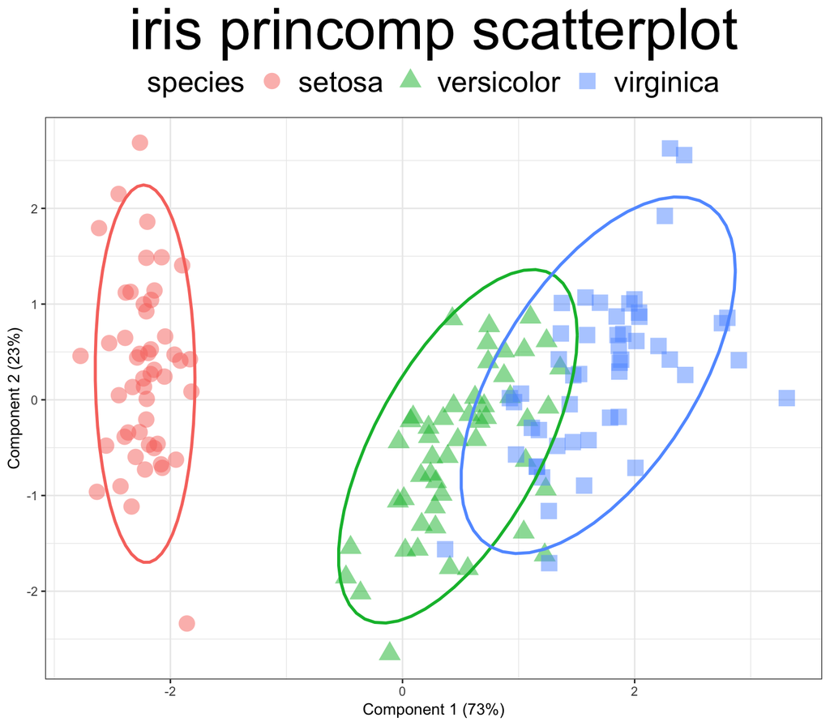

```r
ggplot(pca_princomp_df, aes(x = pca_princomp_df[, 2], y = pca_princomp_df[, 3], color = species, shape = species)) +
  geom_point(size = 5, alpha = 0.5) +
  ggtitle("iris princomp scatterplot") +
  xlab("Component 1 (73%)") +
  ylab("Component 2 (23%)") +
  stat_ellipse(show.legend = FALSE, lwd = 1) +
  labs(color = "species") +
  theme_bw() +
  theme(legend.position = "top",
        plot.title = element_text(hjust = 0.5, size = 40),
        legend.title = element_text(size = 20),
        legend.text = element_text(size = 20))
```

# 9 `princomp` PCA - loadings

##### 9.0.1.0.1 `PCAmix` PCA

If you have mixed data and want to see how you can add factor/categorical variables to your model, check out the excellent [PCAmix package](https://cran.r-project.org/web/packages/PCAmixdata/PCAmixdata.pdf) and look through its awesome [vignette](https://cran.r-project.org/web/packages/PCAmixdata/vignettes/PCAmixdata.html) to get started.

##### 9.0.1.0.2 NA handling

For efficient NA handling, the [`geometric.mean` function from the `psych` package](https://www.rdocumentation.org/packages/psych/versions/1.8.4/topics/geometric.mean) and the [`impute_missing_values` function from the `ck37r` package](https://cran.r-project.org/web/packages/ck37r/README.html) are two ways to get started.

##### 9.0.1.0.3 Interactive 3D plots

Visualizing *three* principal components at once is often useful when your screeplot suggests that more than the first two components should be investigated. To create interactive 3D plots, check out the [`plot3d` function from the `rgl` package](https://cran.r-project.org/web/packages/rgl/vignettes/rgl.html). However, You might need to first install [`XQuartz`](https://www.xquartz.org/).

# 10 PCA - basic machine learning example with `prcomp`

Let’s walk through this example: [Stack Overflow - How to use R prcomp results for prediction?](https://stats.stackexchange.com/questions/72839/how-to-use-r-prcomp-results-for-prediction)

First, create a 70/30 training/test split

```r
# Set seed for reproducibility.
set.seed(1)

# Create a stratified random split.
training_rows = caret::createDataPartition(data$species, p = 0.70, list = FALSE)

train_x = data[training_rows, ] # partition training dataset
test_x = data[-training_rows, ] # partition test dataset

dim(train_x)
```

```
## [1] 105   5
```

```r
dim(test_x)
```

```
## [1] 45  5
```

```r
table(train_x$species)
```

```
##
##     setosa versicolor  virginica
##         35         35         35
```

```r
table(test_x$species)
```

```
##
##     setosa versicolor  virginica
##         15         15         15
```

# 11 fit PCA model to training set

```r
?prcomp
pca_ml = prcomp(train_x[, -1], retx = TRUE, center = TRUE, scale = TRUE)
pca_ml
```

```
## Standard deviations (1, .., p=4):
## [1] 1.6941006 0.9928077 0.3517709 0.1435740
##
## Rotation (n x k) = (4 x 4):
##                     PC1          PC2        PC3        PC4
## Sepal.Length  0.5308227  0.355193790 -0.7286864 -0.2471453
## Sepal.Width  -0.2134604  0.934376653  0.2606210  0.1159812
## Petal.Length  0.5855392 -0.007667963  0.1528061  0.7960750
## Petal.Width   0.5742872  0.026811263  0.6146081 -0.5401224
```

```r
# view percentage of variance explaine
summary(pca_ml)
```

```
## Importance of components:
##                           PC1    PC2     PC3     PC4
## Standard deviation     1.6941 0.9928 0.35177 0.14357
## Proportion of Variance 0.7175 0.2464 0.03094 0.00515
## Cumulative Proportion  0.7175 0.9639 0.99485 1.00000
```

```r
# or
expl.var = round(pca_ml$sdev ^ 2 / sum(pca_ml$sdev ^ 2) * 100, 4)
expl.var
```

```
## [1] 71.7494 24.6417  3.0936  0.5153
```

```r
# generate predicted values of PCs for test dataset
predicted_values = predict(pca_ml, newdata = test_x[,2:5])
head(predicted_values)
```

```
##          PC1        PC2          PC3          PC4
## 2  -2.041675 -0.5211364 -0.266633731 -0.125818070
## 5  -2.281218  0.8478287  0.016193838  0.009271672
## 6  -1.929857  1.6865915  0.037153252 -0.028327537
## 11 -2.044067  1.2384111 -0.261993746 -0.035739680
## 16 -2.059274  2.9203308  0.066414561 -0.071391894
## 17 -2.064590  1.6883559  0.001992577 -0.211504367
```

### 11.0.1 Define some plotting parameters

```r
# assign one color to each species
species_colors = 1:3

# assign one shape for the training data and another shape for the test data
species_shapes = c(1,16)

# which PCs to plot?
num_PCs = c(1,2)
```

### 11.0.2 Store the scores inside of dataframes

```r
# assign the data into dataframes like before
gg_train = data.frame(pca_ml$x[, num_PCs])
str(gg_train)
```

```
## 'data.frame':    105 obs. of  2 variables:
##  $ PC1: num  -2.17 -2.3 -2.25 -2.36 -2.15 ...
##  $ PC2: num  0.669 -0.164 -0.428 0.239 0.405 ...
```

```r
gg_test = data.frame(predicted_values[, num_PCs])
str(gg_test)
```

```
## 'data.frame':    45 obs. of  2 variables:
##  $ PC1: num  -2.04 -2.28 -1.93 -2.04 -2.06 ...
##  $ PC2: num  -0.521 0.848 1.687 1.238 2.92 ...
```

# 12 Construct the scatterplot

We can plot the training and test data on the same plot!

> Squares = training data; ellipses are 95% confidence ellipses for training data  
> Circles = test data

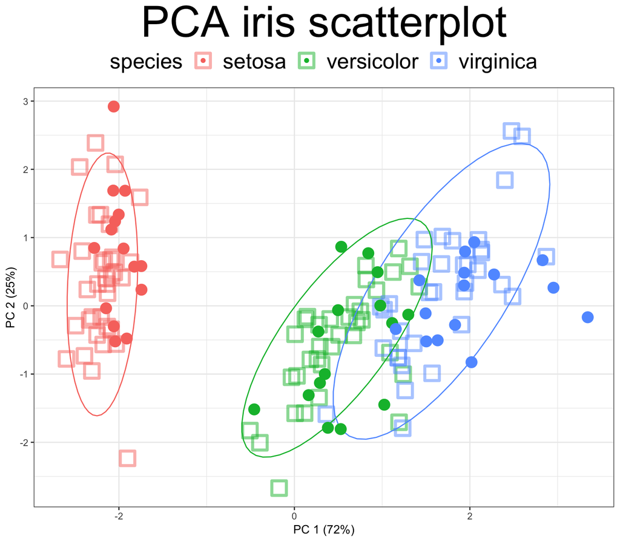

```r
ggplot(

  # training data

  gg_train, aes(x = gg_train[,1], y = gg_train[,2], color = train_x$species)) +
  geom_point(shape = 0, alpha = .5, stroke = 2, size = 5) +
  stat_ellipse(show.legend = F, lwd = 0.5) +
  labs(color = "species") +
  xlab("PC 1 (72%)") +
  ylab("PC 2 (25%)") +
  theme_bw() +

  # test data

  geom_point(gg_test, mapping = aes(x = gg_test[,1], y = gg_test[,2],
                                    color = test_x$species, size = 10)) +
  guides(size = F) +
  theme(legend.position = "top") +
  ggtitle("PCA iris scatterplot") +
  theme(plot.title = element_text(hjust = 0.5, size = 40),
        legend.title = element_text(size = 20),
        legend.text = element_text(size = 20))
```